# Linear regression

## Look at the model diagnistics again

The plots do check out

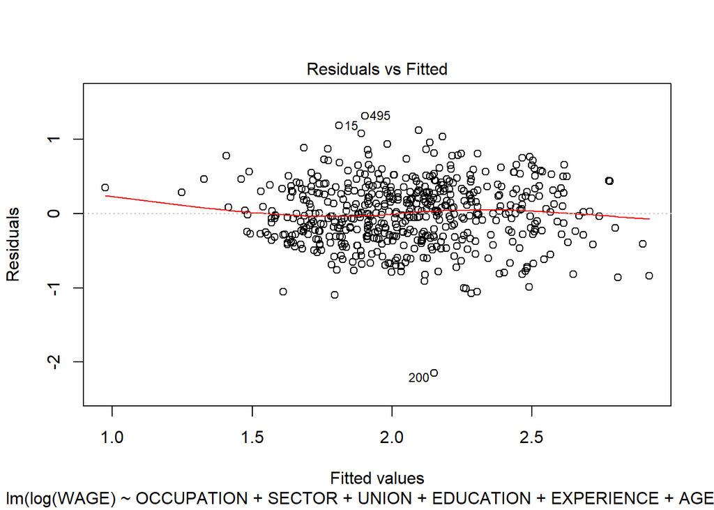

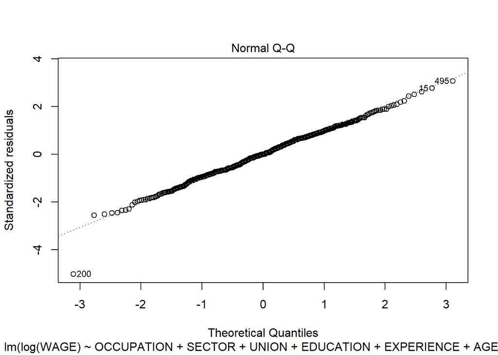

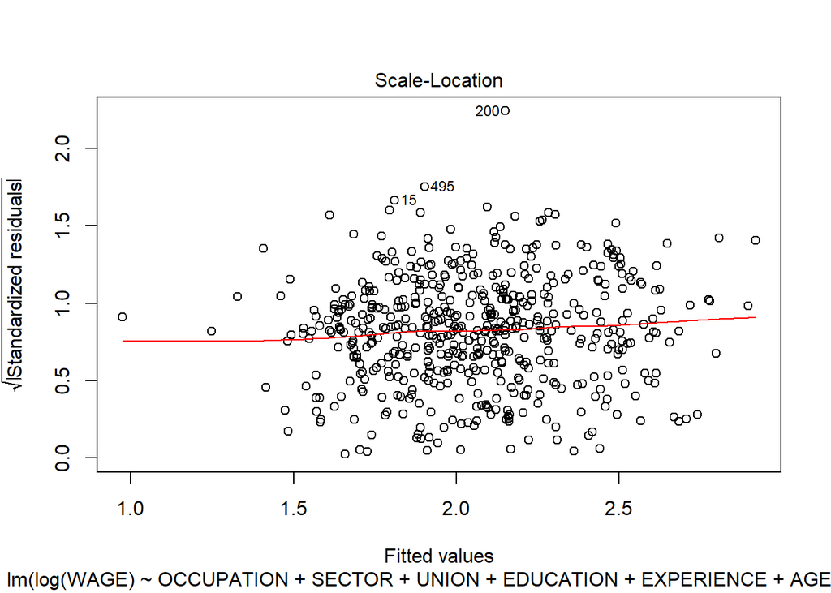

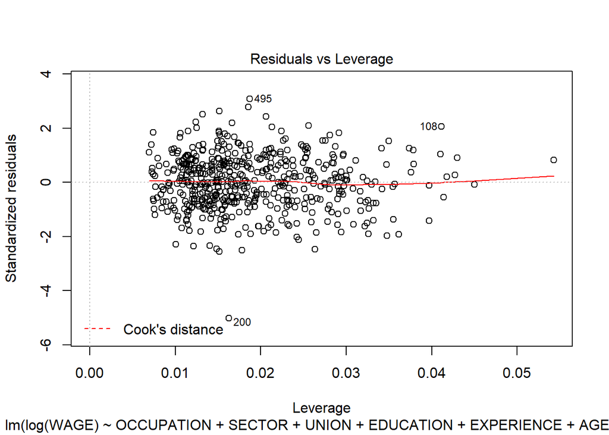

```r
plot(fitAll)
```

Looks like there is a case to be made for multicollinearity. We check multicollinearity using VIFs

## Variance inflation factor

- The variance inflation factor (VIF) provides a measure of how much the variance is inflated.
- Variance of what?
- We know that the standard errors (and, therefore the variances) of the estimated regression coefficients are inflated when multicollinearity exists.
- So, the VIF for the estimated coefficient b<sub>k</sub> (denoted VIF<sub>k</sub>) is the factor by which the variance is inflated.

```r
vif(fitAll)
```

```
##  OCCUPATION      SECTOR       UNION   EDUCATION  EXPERIENCE         AGE
##    1.298166    1.198529    1.120655  231.154656 5166.462753 4630.002872
##         SEX        MARR        RACE       SOUTH
##    1.090626    1.094596    1.037218    1.046716
```

## Visualize the correlations

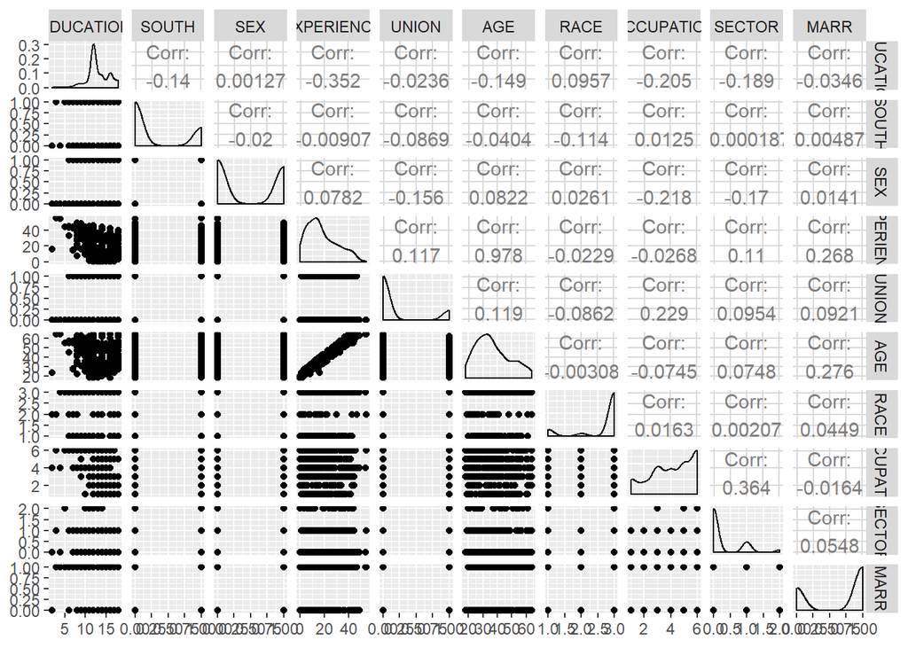

```r
library(GGally)
X <- subset(mydf,select=-c(WAGE))
ggpairs(X)
```

## One more way of looking at correlations

Which one stands out?

```r
round(cor(X),2)
```

```
##            EDUCATION SOUTH   SEX EXPERIENCE UNION   AGE  RACE OCCUPATION
## EDUCATION       1.00 -0.14  0.00      -0.35 -0.02 -0.15  0.10      -0.21
## SOUTH          -0.14  1.00 -0.02      -0.01 -0.09 -0.04 -0.11       0.01
## SEX             0.00 -0.02  1.00       0.08 -0.16  0.08  0.03      -0.22
## EXPERIENCE     -0.35 -0.01  0.08       1.00  0.12  0.98 -0.02      -0.03
## UNION          -0.02 -0.09 -0.16       0.12  1.00  0.12 -0.09       0.23
## AGE            -0.15 -0.04  0.08       0.98  0.12  1.00  0.00      -0.07
## RACE            0.10 -0.11  0.03      -0.02 -0.09  0.00  1.00       0.02
## OCCUPATION     -0.21  0.01 -0.22      -0.03  0.23 -0.07  0.02       1.00
## SECTOR         -0.19  0.00 -0.17       0.11  0.10  0.07  0.00       0.36
## MARR           -0.03  0.00  0.01       0.27  0.09  0.28  0.04      -0.02
##            SECTOR  MARR
## EDUCATION   -0.19 -0.03
## SOUTH        0.00  0.00
## SEX         -0.17  0.01
## EXPERIENCE   0.11  0.27
## UNION        0.10  0.09
## AGE          0.07  0.28
## RACE         0.00  0.04
## OCCUPATION   0.36 -0.02
## SECTOR       1.00  0.05
## MARR         0.05  1.00
```

## What to do?

There are several ways to deal with multicollinearity including using prinicipal components for regression, ridge Regression, or Stepwise Regression.

- We will use the VIF scores to delete the variable with the highest VIF — EXPERIENCE
- Usually, variables with VIF scores > 10 need to be investigated

```r
fitAll1 <- lm(log(WAGE)~OCCUPATION+SECTOR+UNION+EDUCATION+AGE+SEX+MARR+RACE+SOUTH, data = mydf)
summary(fitAll1)
```

```
##
## Call:
## lm(formula = log(WAGE) ~ OCCUPATION + SECTOR + UNION + EDUCATION +
##     AGE + SEX + MARR + RACE + SOUTH, data = mydf)
##
## Residuals:
##      Min       1Q   Median       3Q      Max
## -2.14803 -0.28916 -0.00109  0.29989  1.31089
##
## Coefficients:
##              Estimate Std. Error t value Pr(>|t|)
## (Intercept)  0.458406   0.161938   2.831 0.004822 **
## OCCUPATION  -0.002015   0.012890  -0.156 0.875850
## SECTOR       0.087593   0.037997   2.305 0.021541 *
## UNION        0.196400   0.051471   3.816 0.000152 ***
## EDUCATION    0.084325   0.007582  11.122  < 2e-16 ***
## AGE          0.010761   0.001715   6.275 7.35e-10 ***
## SEX         -0.226532   0.039107  -5.793 1.20e-08 ***
## MARR         0.083945   0.041136   2.041 0.041787 *
## RACE         0.047947   0.027989   1.713 0.087290 .
## SOUTH       -0.098195   0.042005  -2.338 0.019778 *
## ---
## Signif. codes:  0 '***' 0.001 '**' 0.01 '*' 0.05 '.' 0.1 ' ' 1
##
## Residual standard error: 0.4314 on 523 degrees of freedom
## Multiple R-squared:  0.3308, Adjusted R-squared:  0.3192
## F-statistic: 28.72 on 9 and 523 DF,  p-value: < 2.2e-16
```

## Check out the VIFs

```r
vif(fitAll1)
```

```
## OCCUPATION     SECTOR      UNION  EDUCATION        AGE        SEX
##   1.295959   1.198324   1.120541   1.125934   1.154336   1.087298
##       MARR       RACE      SOUTH
##   1.092728   1.037091   1.046185
```

## Alternate approach (stepwise regression)

```r
library(MASS)
fitstep <- lm(log(WAGE)~OCCUPATION+SECTOR+UNION+EDUCATION+EXPERIENCE+AGE+SEX+MARR+RACE+SOUTH, data = mydf)
step <- stepAIC(fitstep, direction="both")
```

```
## Start:  AIC=-885.21
## log(WAGE) ~ OCCUPATION + SECTOR + UNION + EDUCATION + EXPERIENCE +
##     AGE + SEX + MARR + RACE + SOUTH
##
##              Df Sum of Sq     RSS     AIC
## - OCCUPATION  1    0.0070  97.175 -887.17
## - AGE         1    0.1255  97.294 -886.52
## - EXPERIENCE  1    0.1577  97.326 -886.34
## <none>                     97.168 -885.21
## - EDUCATION   1    0.5343  97.702 -884.29
## - RACE        1    0.5396  97.708 -884.26
## - MARR        1    0.8027  97.971 -882.82
## - SOUTH       1    0.9985  98.167 -881.76
## - SECTOR      1    0.9992  98.167 -881.76
## - UNION       1    2.7224  99.891 -872.48
## - SEX         1    6.3350 103.503 -853.54
##
## Step:  AIC=-887.17
## log(WAGE) ~ SECTOR + UNION + EDUCATION + EXPERIENCE + AGE + SEX +
##     MARR + RACE + SOUTH
##
##              Df Sum of Sq     RSS     AIC
## - AGE         1    0.1232  97.298 -888.49
## - EXPERIENCE  1    0.1552  97.330 -888.32
## <none>                     97.175 -887.17
## - EDUCATION   1    0.5313  97.706 -886.26
## - RACE        1    0.5342  97.709 -886.25
## + OCCUPATION  1    0.0070  97.168 -885.21
## - MARR        1    0.8065  97.982 -884.76
## - SOUTH       1    0.9996  98.175 -883.71
## - SECTOR      1    1.0516  98.227 -883.43
## - UNION       1    2.7909  99.966 -874.08
## - SEX         1    6.4005 103.576 -855.17
##
## Step:  AIC=-888.49
## log(WAGE) ~ SECTOR + UNION + EDUCATION + EXPERIENCE + SEX + MARR +
##     RACE + SOUTH
##
##              Df Sum of Sq     RSS     AIC
## <none>                     97.298 -888.49
## - RACE        1    0.5413  97.840 -887.54
## + AGE         1    0.1232  97.175 -887.17
## + OCCUPATION  1    0.0047  97.294 -886.52
## - MARR        1    0.7792  98.078 -886.24
## - SOUTH       1    1.0152  98.314 -884.96
## - SECTOR      1    1.0510  98.349 -884.77
## - UNION       1    2.7875 100.086 -875.44
## - SEX         1    6.3297 103.628 -856.90
## - EXPERIENCE  1    7.5494 104.848 -850.66
## - EDUCATION   1   27.2763 124.575 -758.78
```

```r
step$anova # display results
```

```
## Stepwise Model Path
## Analysis of Deviance Table
##
## Initial Model:
## log(WAGE) ~ OCCUPATION + SECTOR + UNION + EDUCATION + EXPERIENCE +
##     AGE + SEX + MARR + RACE + SOUTH
##
## Final Model:
## log(WAGE) ~ SECTOR + UNION + EDUCATION + EXPERIENCE + SEX + MARR +
##     RACE + SOUTH
##
##
##           Step Df    Deviance Resid. Df Resid. Dev       AIC
## 1                                   522   97.16813 -885.2079
## 2 - OCCUPATION  1 0.007012836       523   97.17514 -887.1695
## 3        - AGE  1 0.123200256       524   97.29834 -888.4941
```

## Lets estimate what stepwise suggested

```r
stepModel <- lm(log(WAGE) ~ SECTOR + UNION + EDUCATION + EXPERIENCE + SEX + MARR +
    RACE + SOUTH, data = mydf)
summary(stepModel)
```

```
##
## Call:
## lm(formula = log(WAGE) ~ SECTOR + UNION + EDUCATION + EXPERIENCE +
##     SEX + MARR + RACE + SOUTH, data = mydf)
##
## Residuals:
##     Min      1Q  Median      3Q     Max
## -2.1423 -0.2883 -0.0007  0.2971  1.3083
##
## Coefficients:
##              Estimate Std. Error t value Pr(>|t|)
## (Intercept)  0.511034   0.139871   3.654 0.000285 ***
## SECTOR       0.085703   0.036023   2.379 0.017712 *
## UNION        0.194626   0.050232   3.875 0.000120 ***
## EDUCATION    0.095355   0.007868  12.120  < 2e-16 ***
## EXPERIENCE   0.010828   0.001698   6.376 3.99e-10 ***
## SEX         -0.225937   0.038698  -5.839 9.24e-09 ***
## MARR         0.084135   0.041072   2.048 0.041010 *
## RACE         0.047649   0.027908   1.707 0.088350 .
## SOUTH       -0.098109   0.041959  -2.338 0.019751 *
## ---
## Signif. codes:  0 '***' 0.001 '**' 0.01 '*' 0.05 '.' 0.1 ' ' 1
##
## Residual standard error: 0.4309 on 524 degrees of freedom
## Multiple R-squared:  0.3309, Adjusted R-squared:  0.3207
## F-statistic:  32.4 on 8 and 524 DF,  p-value: < 2.2e-16
```

## Variable selection

```r
myModel <- lm(log(WAGE) ~ SECTOR + UNION + EDUCATION + EXPERIENCE + SEX + MARR +
    RACE + SOUTH, data = mydf)
k <- ols_step_all_possible(myModel)
k
```

```
## # A tibble: 255 x 6
##    Index     N Predictors          `R-Square` `Adj. R-Square` `Mallow's Cp`
##    <int> <int> <chr>                    <dbl>           <dbl>         <dbl>
##  1     1     1 EDUCATION              0.146           0.144           140.
##  2     2     1 SEX                    0.0519          0.0501          214.
##  3     3     1 UNION                  0.0454          0.0436          219.
##  4     4     1 SOUTH                  0.0287          0.0269          232.
##  5     5     1 MARR                   0.0213          0.0195          237.
##  6     6     1 EXPERIENCE             0.0138          0.0119          243.
##  7     7     1 RACE                   0.00947         0.00760         247.
##  8     8     1 SECTOR                 0.00660         0.00473         249.
##  9     9     2 EDUCATION EXPERIEN~    0.219           0.216            85.1
## 10    10     2 EDUCATION SEX          0.198           0.195           101.
## # ... with 245 more rows
```

## Plot the fits

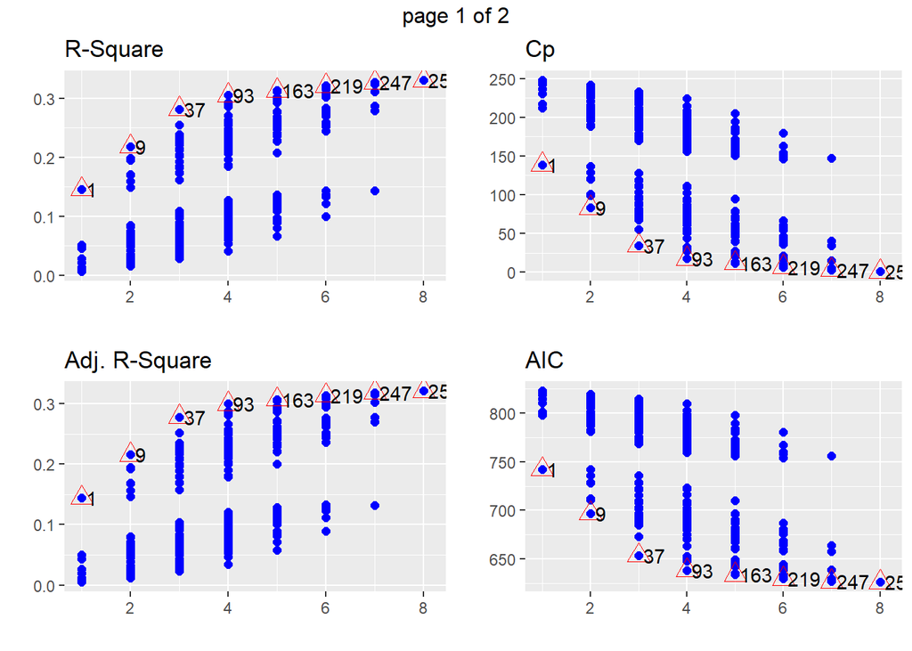

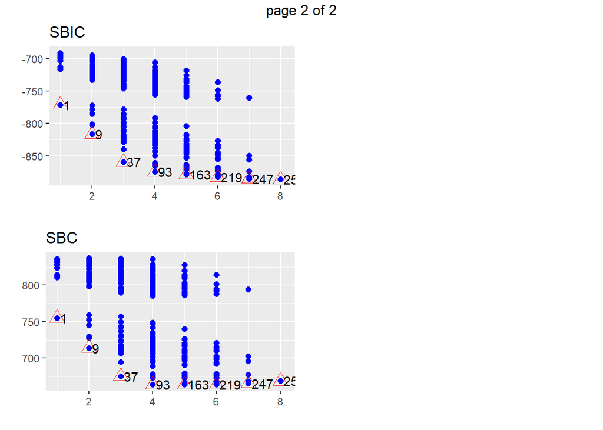

```r
plot(k)
```

## Best Subset Regression

```r
myModel <- lm(log(WAGE) ~ SECTOR + UNION + EDUCATION + EXPERIENCE + SEX + MARR +
    RACE + SOUTH, data = mydf)
k <- ols_step_best_subset(myModel)
k
```

```
##                       Best Subsets Regression
## --------------------------------------------------------------------
## Model Index    Predictors
## --------------------------------------------------------------------
##      1         EDUCATION
##      2         EDUCATION EXPERIENCE
##      3         EDUCATION EXPERIENCE SEX
##      4         UNION EDUCATION EXPERIENCE SEX
##      5         SECTOR UNION EDUCATION EXPERIENCE SEX
##      6         SECTOR UNION EDUCATION EXPERIENCE SEX SOUTH
##      7         SECTOR UNION EDUCATION EXPERIENCE SEX MARR SOUTH
##      8         SECTOR UNION EDUCATION EXPERIENCE SEX MARR RACE SOUTH
## --------------------------------------------------------------------
##
##                                                    Subsets Regression Summary
## ---------------------------------------------------------------------------------------------------------------------------------
##                        Adj.        Pred
## Model    R-Square    R-Square    R-Square      C(p)        AIC         SBIC         SBC        MSEP      FPE       HSP      APC
## ---------------------------------------------------------------------------------------------------------------------------------
##   1        0.1460      0.1443      0.1394    139.8863    742.2115    -771.2721    755.0471    0.2348    0.2348    4e-04    0.8605
##   2        0.2185      0.2156      0.2095     85.0502    696.8813    -816.5155    713.9954    0.2156    0.2156    4e-04    0.7903
##   3        0.2820      0.2779      0.2709     37.3684    653.7591    -859.2526    675.1517    0.1989    0.1989    4e-04    0.7289
##   4        0.3051      0.2998      0.2917     21.2473    638.3015    -874.4945    663.9726    0.1932    0.1932    4e-04    0.7081
##   5        0.3134      0.3069       0.298     16.7260    633.8763    -878.8178    663.8260    0.1916    0.1916    4e-04    0.7022
##   6        0.3213      0.3136      0.3032     12.5171    629.6862    -882.8632    663.9144    0.1901    0.1901    4e-04    0.6967
##   7        0.3272      0.3183      0.3066      9.9150    627.0512    -885.3528    665.5579    0.1892    0.1892    4e-04    0.6933
##   8        0.3309      0.3207      0.3079      9.0000    626.0943    -886.1856    668.8795    0.1889    0.1888    4e-04    0.6920
## ---------------------------------------------------------------------------------------------------------------------------------
## AIC: Akaike Information Criteria
##  SBIC: Sawa's Bayesian Information Criteria
##  SBC: Schwarz Bayesian Criteria
##  MSEP: Estimated error of prediction, assuming multivariate normality
##  FPE: Final Prediction Error
##  HSP: Hocking's Sp
##  APC: Amemiya Prediction Criteria
```

## Plot best subsets

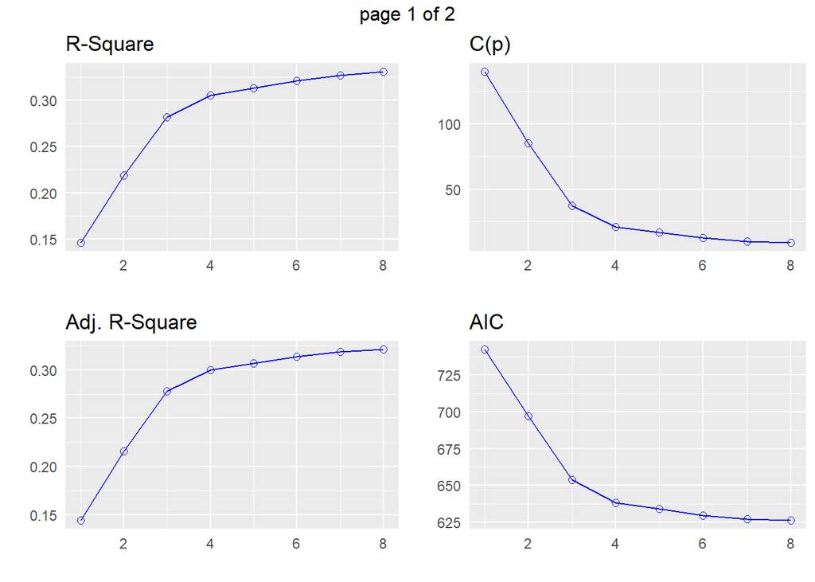

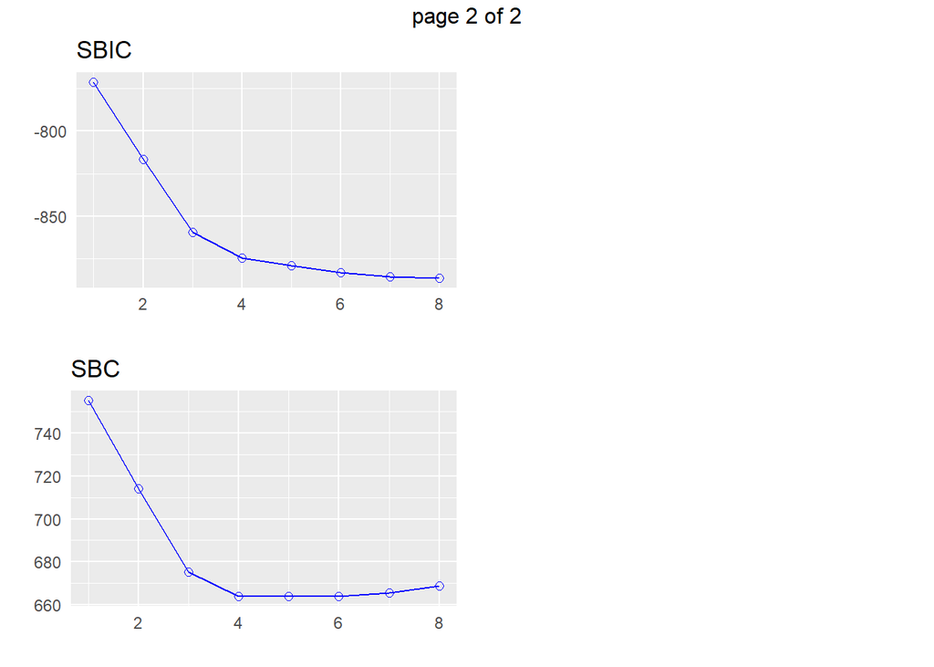

```r
plot(k)
```

## OLS stepwise

```r
myModel <- lm(log(WAGE) ~ SECTOR + UNION + EDUCATION + EXPERIENCE + SEX + MARR +
    RACE + SOUTH, data = mydf)
k <- ols_step_both_p(myModel)
```

```
## Stepwise Selection Method
## ---------------------------
##
## Candidate Terms:
##
## 1. SECTOR
## 2. UNION
## 3. EDUCATION
## 4. EXPERIENCE
## 5. SEX
## 6. MARR
## 7. RACE
## 8. SOUTH
##
## We are selecting variables based on p value...
##
## Variables Entered/Removed:
##
## - EDUCATION added
## - EXPERIENCE added
## - SEX added
## - UNION added
## - SECTOR added
## - SOUTH added
## - MARR added
## - RACE added
##
##
## Final Model Output
## ------------------
##
##                         Model Summary
## --------------------------------------------------------------
## R                       0.575       RMSE                0.431
## R-Squared               0.331       Coef. Var          20.959
## Adj. R-Squared          0.321       MSE                 0.186
## Pred R-Squared          0.308       MAE                 0.341
## --------------------------------------------------------------
##  RMSE: Root Mean Square Error
##  MSE: Mean Square Error
```

[output cut: 11 more lines]

```
##
##                                   Parameter Estimates
## ----------------------------------------------------------------------------------------
##       model      Beta    Std. Error    Std. Beta      t        Sig      lower     upper
## ----------------------------------------------------------------------------------------
## (Intercept)     0.511         0.140                  3.654    0.000     0.236     0.786
##   EDUCATION     0.095         0.008        0.477    12.120    0.000     0.080     0.111
##  EXPERIENCE     0.011         0.002        0.256     6.376    0.000     0.007     0.014
##         SEX    -0.226         0.039       -0.215    -5.839    0.000    -0.302    -0.150
##       UNION     0.195         0.050        0.143     3.875    0.000     0.096     0.293
##      SECTOR     0.086         0.036        0.088     2.379    0.018     0.015     0.156
##       SOUTH    -0.098         0.042       -0.085    -2.338    0.020    -0.181    -0.016
##        MARR     0.084         0.041        0.076     2.048    0.041     0.003     0.165
##        RACE     0.048         0.028        0.062     1.707    0.088    -0.007     0.102
## ----------------------------------------------------------------------------------------
```

```r
k
```

```
##
##                                Stepwise Selection Summary
## ----------------------------------------------------------------------------------------
##                        Added/                   Adj.
## Step     Variable     Removed     R-Square    R-Square      C(p)        AIC        RMSE
## ----------------------------------------------------------------------------------------
##    1    EDUCATION     addition       0.146       0.144    139.8860    742.2115    0.4836
##    2    EXPERIENCE    addition       0.219       0.216     85.0500    696.8813    0.4631
##    3       SEX        addition       0.282       0.278     37.3680    653.7591    0.4443
##    4      UNION       addition       0.305       0.300     21.2470    638.3015    0.4375
##    5      SECTOR      addition       0.313       0.307     16.7260    633.8763    0.4353
##    6      SOUTH       addition       0.321       0.314     12.5170    629.6862    0.4332
##    7       MARR       addition       0.327       0.318      9.9150    627.0512    0.4317
##    8       RACE       addition       0.331       0.321      9.0000    626.0943    0.4309
## ----------------------------------------------------------------------------------------
```

## Plot OLS fits

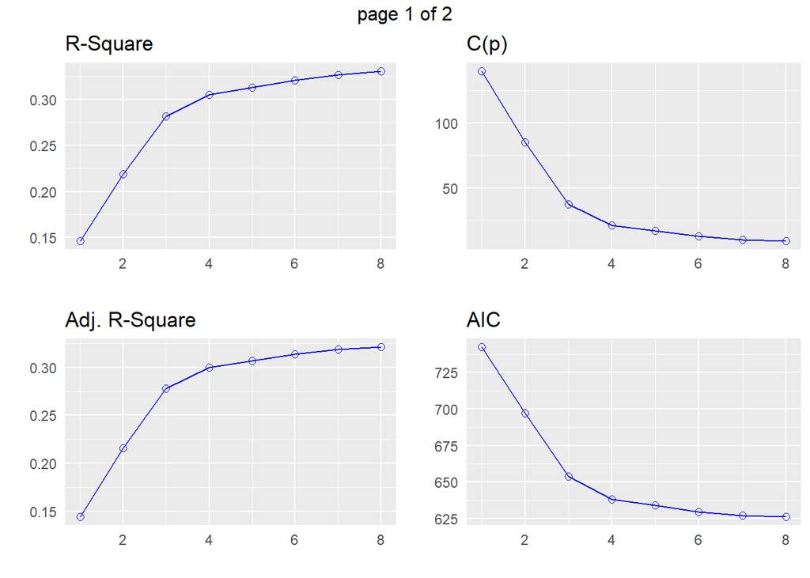

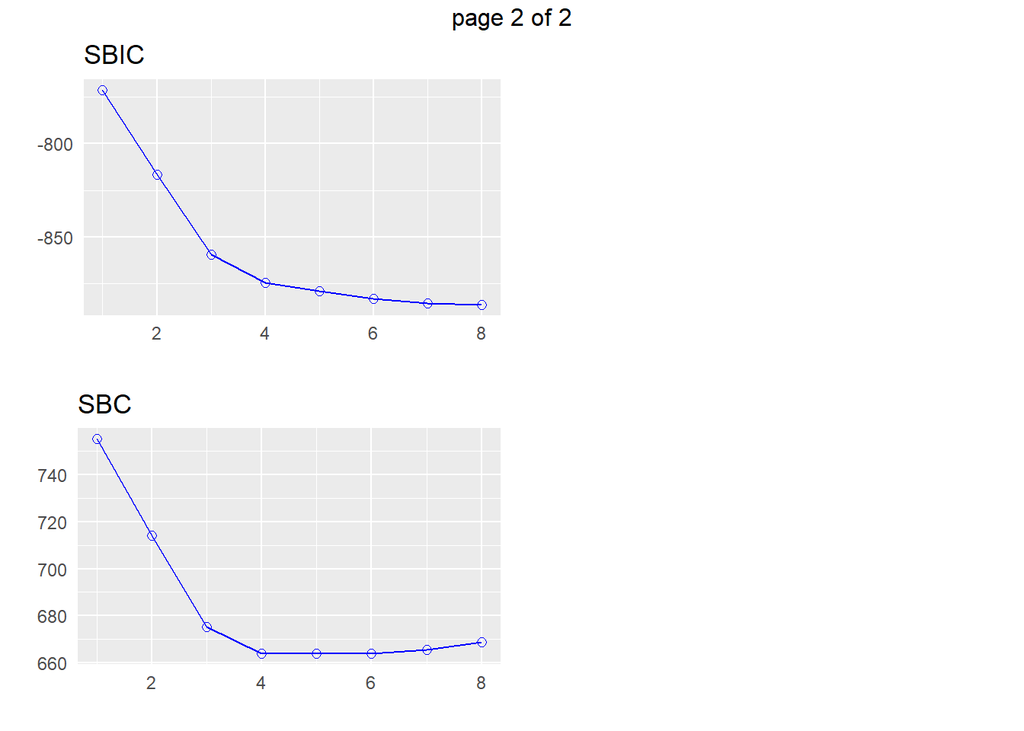

```r
plot(k)
```